# DSA 406 - Project 1

Author

Khushi Chaturvedi

Published

March 5, 2026

## 1 What is EDA?

**Exploratory Data Analysis (EDA)**, is a step in the Data Analysis Process where a number of techniques are used to better understand the dataset being used. EDA is the process of collecting, cleaning, and presenting data for immediate insights. It is the first contact with the data, seeking to answer simple questions such as: Why are our sales decreasing? What types of people are buying our products?

*The significance of EDA in data science:*

- This helps extract important variables and leave behind useless ones.
- It identifies outliers, missing values, or human error in the dataset.
- It reveals relationships between variables as well as patterns and trends.
- This helps choose the best machine learning and statistical techniques.
- This guarantees that the analysis findings are reliable and helpful for decision making.

*EDA methods can be cross-classified as:*

- **Graphical or non-graphical methods**
- **Univariate** (only one variable) methods
- **Multivariate** (several variables) methods

*The three main components of EDA are:*

1. **Understanding your variables** such as using functions like `glimpse()`, `str()`, `head()`.
2. **Cleaning your dataset** means removing duplicates, handling missing values, fixing data types.
3. **Analyzing plots and descriptive statistics** means using histograms, boxplots, scatterplots, and summary tables.

## 2 Research Question / Objective

Using the YouTube-BoundingBoxes (YT-BB) dataset, my objective is to explore the distribution of object classes across video segments, understand how bounding box annotations are distributed, and identify any patterns in how objects appear across frames and videos.

**Research Question:** What are the most commonly annotated object classes in the YT-BB dataset, and how do bounding box dimensions vary across classes?

## 3 What is Data Wrangling?

**Data wrangling** is a process of working with raw data and transforming it to a format where it can be passed to further EDA. Data wrangling consists of three steps that are **gather** (collect), **assess** (evaluate), and **clean** where the quality and tidiness of the data set are examined.

The key data wrangling functions are:

- `select()` — for looking at specific columns (variables)
- `filter()` — for looking at specific rows (cases)
- `mutate()` — for defining new variables from old ones
- `group_by()` — for splitting a data set into groups
- `rename()` — for renaming columns
- `arrange()` — for sorting a data frame by a specific variable
- `distinct()` — for removing duplicate rows
- `complete.cases()` / `na.omit()` — for handling missing values

## 4 Descriptive Statistics and Data Distribution

Descriptive statistics summarize the key characteristics of a dataset. When describing or examining data, we are typically concerned with:

- **Measures of Central Tendency**: Mean (arithmetic average), Median (middle value), Mode (most frequent value)
- **Measures of Spread**: Variance, Standard Deviation, Interquartile Range (IQR), Min, Max
- **Shape of Distribution**: Skewness and Kurtosis

**Skewness** is a measure of a distribution’s asymmetry. A distribution can be skewed left (negative), symmetric (normal/bell-shaped), or skewed right (positive). Skewness is important because many models assume variables are normally distributed.

**Kurtosis** quantifies the tails of a distribution. This means high kurtosis (leptokurtic) means heavier tails and more outliers, while low kurtosis (platykurtic) means lighter tails.

**Important rule:**

- Symmetrical distribution and N > 30 → express results as **mean ± standard deviation**
- Asymmetrical distribution or N < 30 or evidence for outliers → use **median ± IQR**

## 5 Setup: Load Packages

```r
# install.packages("tidyverse")
# install.packages("skimr")
# install.packages("janitor")
# install.packages("rmarkdown")

library(tidyverse)   # Core data manipulation and visualization suite
library(ggplot2)     # For creating plots and graphs
library(dplyr)       # For data wrangling (filter, mutate, summarize, etc.)
library(readr)       # For reading CSV files efficiently
library(skimr)       # For a quick summary/skim of the dataset
library(janitor)     # For cleaning column names
library(rmarkdown)   # For paged_table() to display large tables
```

## 6 Load the Dataset

The YT-BB dataset comes without column headers, so we define them manually.

```r
# read_csv() from the readr package reads the CSV file
# col_names defines the column headers manually since the file has none
# n_max limits rows loaded to prevent memory crashes
df <- read_csv(
  "youtube_boundingboxes_detection_train.csv",
  col_names = c("youtube_id", "timestamp_ms", "class_id",
                "class_name", "object_id", "object_presence",
                "xmin", "xmax", "ymin", "ymax"),
  n_max = 100000
)

# clean_names() from janitor makes all column names lowercase
df <- df %>% clean_names()
```

## 7 Understanding the Dataset

```r
# dim() tells us the number of rows and columns
dim(df)
```

```
[1] 100000     10
```

```r
# str() shows the structure, data types, and a preview of each variable
str(df)
```

```
spc_tbl_ [100,000 × 10] (S3: spec_tbl_df/tbl_df/tbl/data.frame)
 $ youtube_id     : chr [1:100000] "AAB6lO-XiKE" "AAB6lO-XiKE" "AAB6lO-XiKE" "AAB6lO-XiKE" ...
 $ timestamp_ms   : num [1:100000] 238000 239000 240000 241000 242000 243000 244000 245000 246000 247000 ...
 $ class_id       : num [1:100000] 0 0 0 0 0 0 0 0 0 0 ...
 $ class_name     : chr [1:100000] "person" "person" "person" "person" ...
 $ object_id      : num [1:100000] 0 0 0 0 0 0 0 0 0 0 ...
 $ object_presence: chr [1:100000] "present" "present" "present" "present" ...
 $ xmin           : num [1:100000] 0.482 0.514 0.534 0.515 0.55 0.539 0.55 0.584 0.618 0.643 ...
 $ xmax           : num [1:100000] 0.54 0.588 0.614 0.605 0.6 0.607 0.593 0.627 0.659 0.689 ...
 $ ymin           : num [1:100000] 0.372 0.363 0.443 0.448 0.4 ...
 $ ymax           : num [1:100000] 0.617 0.607 0.685 0.687 0.638 ...
 - attr(*, "spec")=
  .. cols(
  ..   youtube_id = col_character(),
  ..   timestamp_ms = col_double(),
  ..   class_id = col_double(),
  ..   class_name = col_character(),
  ..   object_id = col_double(),
  ..   object_presence = col_character(),
  ..   xmin = col_double(),
  ..   xmax = col_double(),
  ..   ymin = col_double(),
  ..   ymax = col_double()
  .. )
 - attr(*, "problems")=<externalptr>
```

```r
# glimpse() is a dplyr function: shows column names, types, and sample values
glimpse(df)
```

```
Rows: 100,000
Columns: 10
$ youtube_id      <chr> "AAB6lO-XiKE", "AAB6lO-XiKE", "AAB6lO-XiKE", "AAB6lO-X…
$ timestamp_ms    <dbl> 238000, 239000, 240000, 241000, 242000, 243000, 244000…
$ class_id        <dbl> 0, 0, 0, 0, 0, 0, 0, 0, 0, 0, 0, 0, 0, 0, 0, 0, 0, 0, …
$ class_name      <chr> "person", "person", "person", "person", "person", "per…
$ object_id       <dbl> 0, 0, 0, 0, 0, 0, 0, 0, 0, 0, 0, 0, 0, 0, 0, 0, 0, 0, …
$ object_presence <chr> "present", "present", "present", "present", "present",…
$ xmin            <dbl> 0.482, 0.514, 0.534, 0.515, 0.550, 0.539, 0.550, 0.584…
$ xmax            <dbl> 0.540, 0.588, 0.614, 0.605, 0.600, 0.607, 0.593, 0.627…
$ ymin            <dbl> 0.3716667, 0.3633333, 0.4433333, 0.4483333, 0.4000000,…
$ ymax            <dbl> 0.6166667, 0.6066667, 0.6850000, 0.6866667, 0.6383333,…
```

```r
# skim() provides a rich statistical summary including missingness and distributions
skim(df)
```

Data summary

| Name | df |
| --- | --- |
| Number of rows | 100000 |
| Number of columns | 10 |
| _______________________ |  |
| Column type frequency: |  |
| character | 3 |
| numeric | 7 |
| ________________________ |  |
| Group variables | None |

**Variable type: character**

| skim_variable | n_missing | complete_rate | min | max | empty | n_unique | whitespace |
| --- | --- | --- | --- | --- | --- | --- | --- |
| youtube_id | 0 | 1 | 11 | 11 | 0 | 3386 | 0 |
| class_name | 0 | 1 | 3 | 12 | 0 | 23 | 0 |
| object_presence | 0 | 1 | 6 | 9 | 0 | 3 | 0 |

**Variable type: numeric**

| skim_variable | n_missing | complete_rate | mean | sd | p0 | p25 | p50 | p75 | p100 | hist |
| --- | --- | --- | --- | --- | --- | --- | --- | --- | --- | --- |
| timestamp_ms | 0 | 1 | 154790.72 | 263164.63 | 0 | 2.9e+04 | 7.8e+04 | 1.82e+05 | 3.571e+06 | ▇▁▁▁▁ |
| class_id | 0 | 1 | 8.60 | 7.31 | 0 | 1.0e+00 | 8.0e+00 | 1.50e+01 | 2.300e+01 | ▇▃▃▃▃ |
| object_id | 0 | 1 | 0.98 | 2.60 | 0 | 0.0e+00 | 0.0e+00 | 1.00e+00 | 3.700e+01 | ▇▁▁▁▁ |
| xmin | 0 | 1 | 0.02 | 0.54 | -1 | 0.0e+00 | 1.6e-01 | 3.70e-01 | 9.900e-01 | ▅▁▇▇▂ |
| xmax | 0 | 1 | 0.40 | 0.72 | -1 | 3.7e-01 | 6.8e-01 | 9.10e-01 | 1.000e+00 | ▂▁▁▃▇ |
| ymin | 0 | 1 | 0.00 | 0.53 | -1 | 0.0e+00 | 1.4e-01 | 3.40e-01 | 9.800e-01 | ▅▁▇▇▁ |
| ymax | 0 | 1 | 0.47 | 0.74 | -1 | 5.2e-01 | 7.8e-01 | 1.00e+00 | 1.000e+00 | ▂▁▁▁▇ |

```r
# head() shows the first 6 rows: useful for a quick preview of the data
head(df)
```

```
# A tibble: 6 × 10
  youtube_id  timestamp_ms class_id class_name object_id object_presence  xmin
  <chr>              <dbl>    <dbl> <chr>          <dbl> <chr>           <dbl>
1 AAB6lO-XiKE       238000        0 person             0 present         0.482
2 AAB6lO-XiKE       239000        0 person             0 present         0.514
3 AAB6lO-XiKE       240000        0 person             0 present         0.534
4 AAB6lO-XiKE       241000        0 person             0 present         0.515
5 AAB6lO-XiKE       242000        0 person             0 present         0.55
6 AAB6lO-XiKE       243000        0 person             0 present         0.539
# ℹ 3 more variables: xmax <dbl>, ymin <dbl>, ymax <dbl>
```

**Explanation:**

- `dim()` returns the number of rows and columns in the dataset.
- `str()` shows the structure and data types of each variable. This is important for identifying whether variables need type conversion.
- `glimpse()` is a dplyr function that provides a compact view of column names, types, and sample values.
- `skim()` gives a richer summary including missingness, min/max, and distribution information.
- `head()` returns the first few rows so we can see example values for each variable.

## 8 Variables of Interest

This dataset contains **100000 rows** and **10 columns**. The variables used here are:

| Variable | Type | Description |
| --- | --- | --- |
| `class_name` | Categorical (character) | The object category label (e.g., “cat”, “car”) |
| `object_presence` | Categorical (character) | Whether the object is present or absent in the frame |
| `xmin`, `xmax`, `ymin`, `ymax` | Numeric (continuous) | Bounding box coordinates (normalized 0 - 1) |
| `youtube_id` | Categorical (character) | Unique video identifier |
| `timestamp_ms` | Numeric (discrete) | Timestamp in milliseconds |
| `class_id` | Numeric (integer) | Numeric ID corresponding to the class name |

Note: `class_name` and `object_presence` are **nominal categorical** variables (no natural order), while `xmin`, `xmax`, `ymin`, `ymax` are **continuous numerical** variables that can be divided infinitely.

## 9 Data Wrangling

### 9.1 Check and Handle Missing Values

```r
# any(is.na()) checks if there are ANY missing values in the dataset and returns TRUE if missing values exist
any(is.na(df))
```

```
[1] FALSE
```

```r
# colSums(is.na()) counts missing values per column
colSums(is.na(df))
```

```
     youtube_id    timestamp_ms        class_id      class_name       object_id
              0               0               0               0               0
object_presence            xmin            xmax            ymin            ymax
              0               0               0               0               0
```

```r
# Using complete.cases() to keep only rows with no missing values
# This returns a logical vector — TRUE for complete rows
rowscomplete <- complete.cases(df)
df_clean <- df[rowscomplete, ]

# paged_table() from rmarkdown package displays large tables in a paginated format
paged_table(df_clean)
```

| youtube_id | timestamp_ms | class_id | class_name | object_id | object_presence | xmin | xmax | ymin | ymax |
| --- | --- | --- | --- | --- | --- | --- | --- | --- | --- |
| AAB6lO-XiKE | 238000 | 0 | person | 0 | present | 0.482 | 0.540 | 0.371666670 | 0.61666670 |
| AAB6lO-XiKE | 239000 | 0 | person | 0 | present | 0.514 | 0.588 | 0.363333340 | 0.60666670 |
| AAB6lO-XiKE | 240000 | 0 | person | 0 | present | 0.534 | 0.614 | 0.443333330 | 0.68500000 |
| AAB6lO-XiKE | 241000 | 0 | person | 0 | present | 0.515 | 0.605 | 0.448333320 | 0.68666667 |
| AAB6lO-XiKE | 242000 | 0 | person | 0 | present | 0.550 | 0.600 | 0.400000000 | 0.63833330 |
| AAB6lO-XiKE | 243000 | 0 | person | 0 | present | 0.539 | 0.607 | 0.360000000 | 0.60666670 |
| AAB6lO-XiKE | 244000 | 0 | person | 0 | present | 0.550 | 0.593 | 0.355000000 | 0.59500000 |
| AAB6lO-XiKE | 245000 | 0 | person | 0 | present | 0.584 | 0.627 | 0.331666680 | 0.57833330 |
| AAB6lO-XiKE | 246000 | 0 | person | 0 | present | 0.618 | 0.659 | 0.251666670 | 0.49166667 |
| AAB6lO-XiKE | 247000 | 0 | person | 0 | present | 0.643 | 0.689 | 0.228333340 | 0.47500000 |

[output cut: 9990 more lines]

**Explanation:** `complete.cases()` examines each row and returns `TRUE` only if all values in that row are present. This is preferred over `na.omit()` when we want more flexibility in subsetting.

### 9.2 Convert Data Types

```r
# mutate() with across() converts categorical columns to factor type
# Factor is the correct data type for categorical variables in R
df_clean <- df_clean %>%
  mutate(across(c(class_name, object_presence), as.factor))

# Verify the changes
glimpse(df_clean)
```

```
Rows: 100,000
Columns: 10
$ youtube_id      <chr> "AAB6lO-XiKE", "AAB6lO-XiKE", "AAB6lO-XiKE", "AAB6lO-X…
$ timestamp_ms    <dbl> 238000, 239000, 240000, 241000, 242000, 243000, 244000…
$ class_id        <dbl> 0, 0, 0, 0, 0, 0, 0, 0, 0, 0, 0, 0, 0, 0, 0, 0, 0, 0, …
$ class_name      <fct> person, person, person, person, person, person, person…
$ object_id       <dbl> 0, 0, 0, 0, 0, 0, 0, 0, 0, 0, 0, 0, 0, 0, 0, 0, 0, 0, …
$ object_presence <fct> present, present, present, present, present, present, …
$ xmin            <dbl> 0.482, 0.514, 0.534, 0.515, 0.550, 0.539, 0.550, 0.584…
$ xmax            <dbl> 0.540, 0.588, 0.614, 0.605, 0.600, 0.607, 0.593, 0.627…
$ ymin            <dbl> 0.3716667, 0.3633333, 0.4433333, 0.4483333, 0.4000000,…
$ ymax            <dbl> 0.6166667, 0.6066667, 0.6850000, 0.6866667, 0.6383333,…
```

**Explanation:** `across()` from the dplyr package applies a function to multiple columns at once. Here we convert `class_name` and `object_presence` to **factor** type, since they are categorical variables with a limited number of unique values.

### 9.3 Filter and Create New Variables

```r
# filter() keeps only rows where object_presence equals "present"
df_present <- df_clean %>%
  filter(object_presence == "present")

# mutate() creates new columns derived from existing ones
# We calculate bounding box width, height, and area
df_present <- df_present %>%
  mutate(
    bb_width  = xmax - xmin,
    bb_height = ymax - ymin,
    bb_area   = bb_width * bb_height
  )

# count() tallies the number of rows per class sorted from highest to lowest
class_counts <- df_present %>%
  count(class_name, sort = TRUE)

# paged_table() displays the result in a scrollable table
paged_table(class_counts)
```

| class_name | n |
| --- | --- |
| person | 18973 |
| horse | 4557 |
| train | 4058 |
| airplane | 3884 |
| cat | 3716 |
| knife | 3568 |
| elephant | 3444 |
| truck | 3206 |
| bird | 3186 |
| bear | 3110 |

[output cut: 13 more lines]

**Explanation:**

- `filter()` subsets rows based on a condition. Here we keep only rows where the object is present.
- `mutate()` creates new columns from existing ones. We calculate width, height, and area of each bounding box.
- `count()` tallies how many rows exist per group. Here, per object class.

### 9.4 Descriptive Statistics

```r
# summary() provides min, max, mean, median, and quartiles for numeric variables
summary(df_present[, c("xmin", "xmax", "ymin", "ymax", "bb_width", "bb_height", "bb_area")])
```

```
      xmin             xmax             ymin              ymax
 Min.   :0.0000   Min.   :0.0080   Min.   :0.00000   Min.   :0.0000
 1st Qu.:0.0550   1st Qu.:0.5880   1st Qu.:0.05167   1st Qu.:0.7017
 Median :0.2460   Median :0.7680   Median :0.22000   Median :0.8650
 Mean   :0.2667   Mean   :0.7419   Mean   :0.24173   Mean   :0.8245
 3rd Qu.:0.4210   3rd Qu.:0.9630   3rd Qu.:0.38000   3rd Qu.:1.0000
 Max.   :0.9920   Max.   :1.0000   Max.   :0.98167   Max.   :1.0000
    bb_width        bb_height         bb_area
 Min.   :0.0070   Min.   :0.0000   Min.   :0.00000
 1st Qu.:0.2180   1st Qu.:0.3500   1st Qu.:0.08845
 Median :0.4280   Median :0.5783   Median :0.23920
 Mean   :0.4752   Mean   :0.5828   Mean   :0.32338
 3rd Qu.:0.7090   3rd Qu.:0.8333   3rd Qu.:0.49275
 Max.   :1.0000   Max.   :1.0000   Max.   :1.00000
```

**Explanation:** `summary()` gives us the five-number summary (minimum, Q1, median, Q3, maximum) plus the mean for each numeric variable. This helps us understand central tendency and spread, and lets us identify potential outliers.

## 10 EDA: Visualizations

### 10.1 Plot 1 — Top 10 Most Common Object Classes

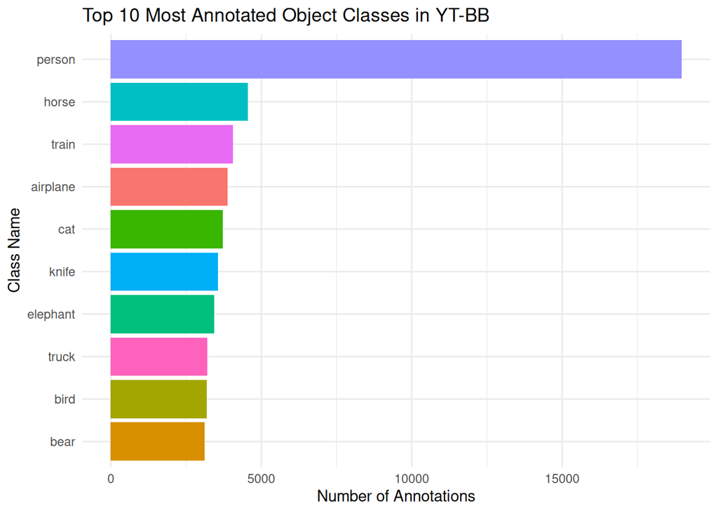

```r
class_counts %>%
  slice_head(n = 10) %>%
  ggplot(aes(x = reorder(class_name, n), y = n, fill = class_name)) +
  geom_col(show.legend = FALSE) +
  coord_flip() +
  labs(
    title = "Top 10 Most Annotated Object Classes in YT-BB",
    x = "Class Name",
    y = "Number of Annotations"
  ) +
  theme_minimal()
```

### 10.2 Plot 2 — Distribution of Bounding Box Areas (Histogram)

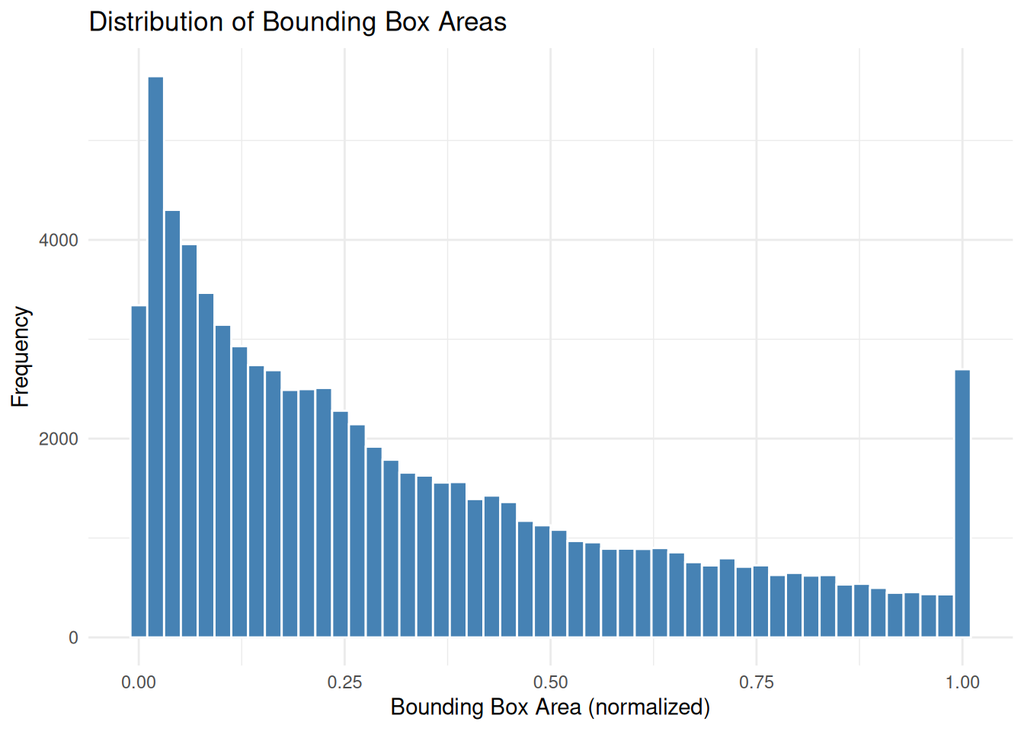

```r
df_present %>%
  filter(bb_area > 0, bb_area <= 1) %>%
  ggplot(aes(x = bb_area)) +
  geom_histogram(bins = 50, fill = "steelblue", color = "white") +
  labs(
    title = "Distribution of Bounding Box Areas",
    x = "Bounding Box Area (normalized)",
    y = "Frequency"
  ) +
  theme_minimal()
```

**Interpretation:** The distribution of bounding box areas is heavily **right-skewed (positive skew)**, meaning most objects occupy a small portion of the video frame. As covered in class, a right-skewed distribution means the mean is greater than the median, and we should use **median ± IQR** to describe this variable rather than mean ± SD.

### 10.3 Plot 3 — Boxplot of Bounding Box Width by Top 5 Classes

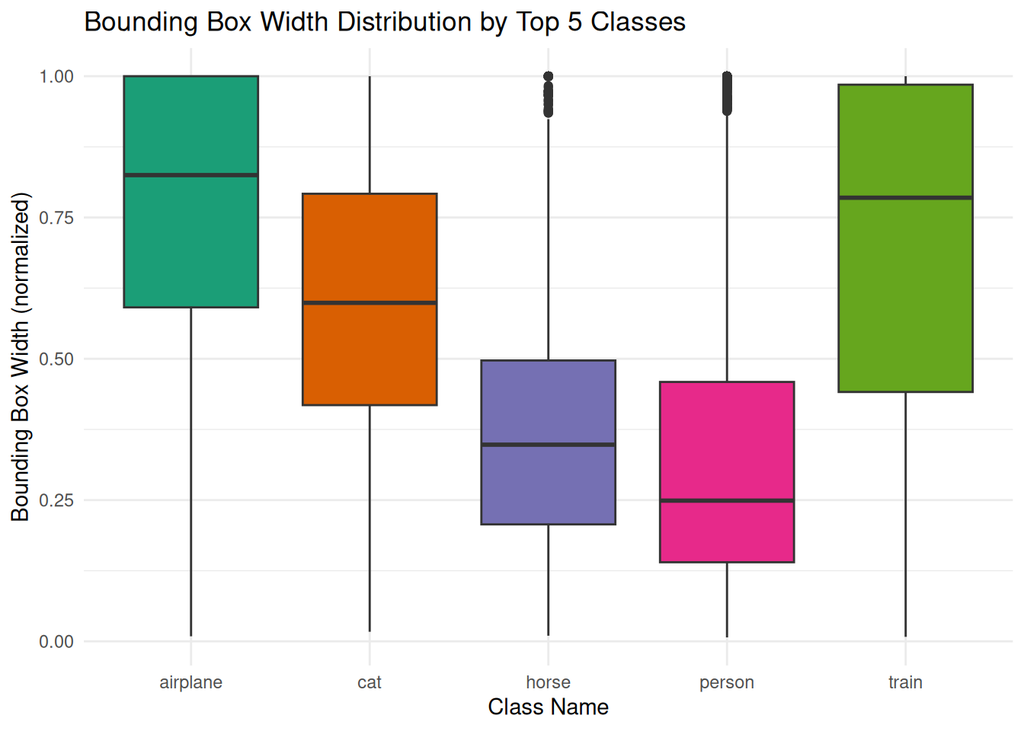

```r
top5_classes <- class_counts %>% slice_head(n = 5) %>% pull(class_name)

df_present %>%
  filter(class_name %in% top5_classes) %>%
  ggplot(aes(x = class_name, y = bb_width, fill = class_name)) +
  geom_boxplot(show.legend = FALSE) +
  scale_fill_brewer(palette = "Dark2") +
  labs(
    title = "Bounding Box Width Distribution by Top 5 Classes",
    x = "Class Name",
    y = "Bounding Box Width (normalized)"
  ) +
  theme_minimal()
```

**Interpretation:** The boxplot shows the distribution of bounding box widths for the top 5 object classes. The horizontal line inside each box is the **median (Q2)**. The box spans from **Q1 (25th percentile)** to **Q3 (75th percentile)**, representing the IQR. Points outside the fences (Q1 - 1.5×IQR and Q3 + 1.5×IQR) are **outliers**. Different classes show different width distributions, suggesting objects vary significantly in size within the frame.

### 10.4 Plot 4 — Bounding Box Width vs Height (Scatterplot, Top 5 Classes)

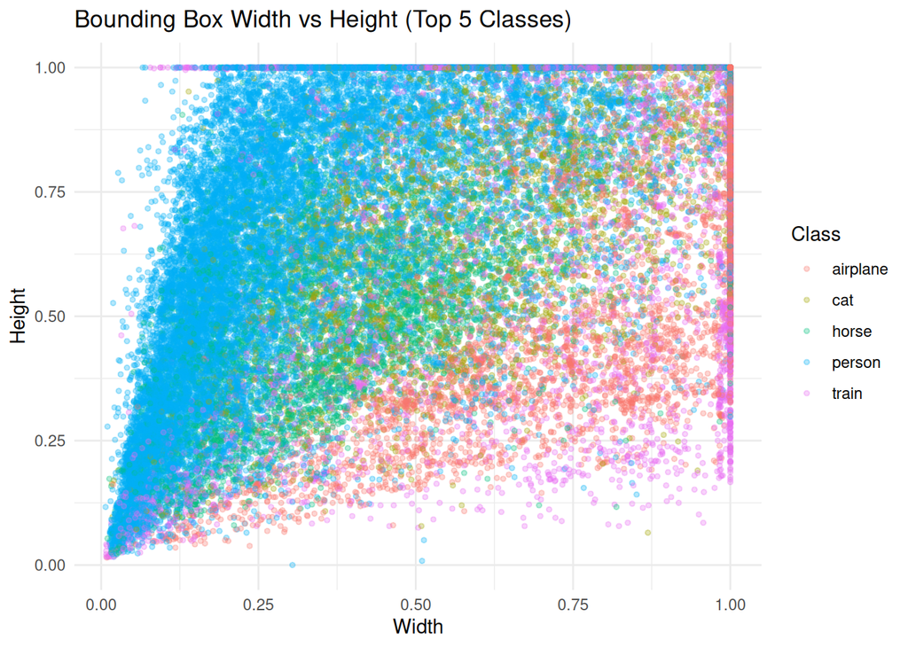

```r
df_present %>%
  filter(class_name %in% top5_classes) %>%
  ggplot(aes(x = bb_width, y = bb_height, color = class_name)) +
  geom_point(alpha = 0.3, size = 1) +
  labs(
    title = "Bounding Box Width vs Height (Top 5 Classes)",
    x = "Width", y = "Height", color = "Class"
  ) +
  theme_minimal()
```

**Interpretation:** This scatterplot visualizes the relationship between bounding box width and height for each class. A positive trend suggests that wider bounding boxes also tend to be taller meaning larger objects overall. Different classes cluster differently, indicating distinct aspect ratios per object type.

### 10.5 Plot 5 — Object Presence vs Absence

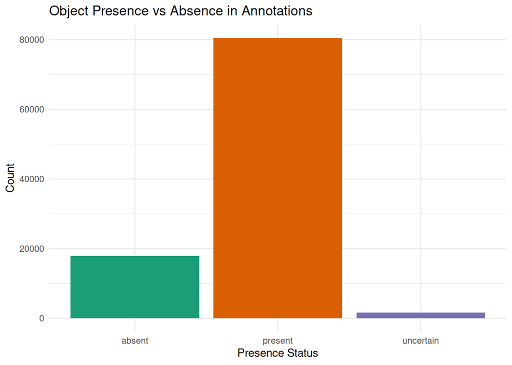

```r
df_clean %>%
  count(object_presence) %>%
  ggplot(aes(x = object_presence, y = n, fill = object_presence)) +
  geom_col(show.legend = FALSE) +
  scale_fill_brewer(palette = "Dark2") +
  labs(
    title = "Object Presence vs Absence in Annotations",
    x = "Presence Status",
    y = "Count"
  ) +
  theme_minimal()
```

**Interpretation:** This chart shows the balance between frames where an object is present versus absent. A large imbalance between present and absent annotations could affect the quality of any predictive model built on this data.

## 11 Summary

In this project we:

- Loaded and cleaned the YT-BB detection dataset using `read_csv()`, `clean_names()`, and `complete.cases()`
- Identified and described key variables including their data types (categorical vs. numerical)
- Performed data wrangling: handled missing values, converted data types using `mutate()` and `across()`, and created new bounding box dimension variables
- Computed descriptive statistics using `summary()` and `skim()` to understand central tendency and spread
- Created 5 visualizations: a bar chart, histogram, boxplot, scatterplot, and presence chart with interpretations for each.

The dataset contains **100000 observations** across **10 variables**. The bounding box area distribution is right skewed, class annotations are imbalanced, and different object classes show distinct spatial patterns in their bounding box dimensions.